# LP2I2_Aula15_IntegracaoComBancoDados

[figure not shown]

Instituto Federal de São Paulo (IFSP)  
[Campus Bragança Paulista/SP](https://bra.ifsp.edu.br)  
**Análise e Desenvolvimento de Sistemas (ADS)**  
**2o. módulo**  
**Profa. Ana Paula Müller Giancoli**  
paulagiancoli@ifsp.edu.br

[figure not shown]

## AULA 15 - Integração com Banco de Dados

### Agenda

- Sqlite3
- Executando um exemplo
- MySQL - Configuração
- Executando um exemplo
- Perguntas

### Configuração

- Manipulando dados de um banco de dados.
- Vamos utilizar:
  - **Linguagem de programação**: python
  - **Banco de dados**: SQLite3
  - **Conector Python**: específico para a versão do seu BD com python.

### 1. SQLite3

- De acordo com [Sqlite - Site Oficial](https://www.sqlite.org/index.html):
  - O **SQLite** é uma **biblioteca em linguagem C** que implementa um **mecanismo de banco de dados SQL** pequeno, rápido, independente, de alta confiabilidade e completo.
  - O **SQLite** é o *mecanismo de banco de dados mais usado no mundo*.
  - O **SQLite está embutido** em todos os **telefones celulares e na maioria dos computadores** e é fornecido em inúmeras outras aplicações que as pessoas usam todos os dias.
  - É estável, multi-plataforma.
  - Os **arquivos de banco de dados SQLite** são comumente usados como recipientes para transferir conteúdo rico entre sistemas e como formato de arquivamento de longo prazo para dados.
  - Existem mais de 1 trilhão de bancos de dados SQLite em uso ativo.
  - O **SQLite suporta nativamente apenas os tipos TEXT, INTEGER, REAL, BLOB e NULL**.

#### **Observação**:

- Para aprofundamento: quando usar, especificações, versões etc. Consulte [SQLite](https://www.sqlite.org/).
- Ou, consulte: [Python-Sqlite3 API](https://docs.python.org/pt-br/3.8/library/sqlite3.html#module-sqlite3).
- Para outras informações: [SQLite Tutorial](https://www.sqlitetutorial.net/sqlite-python/).

### 1.1. **Funções e constantes do Módulo SQLite**

- Para aprofundamento e conhecimento, acesse [Funções-SQLite](https://docs.python.org/3.8/library/sqlite3.html#module-functions-and-constants).

| Função | Descrição |
| --- | --- |
| **sqlite3.version** | O número da versão deste módulo, como uma sequência. Esta não é a versão da biblioteca SQLite. |
| **sqlite3.sqlite_version** | O número da versão da biblioteca SQLite em tempo de execução, como uma sequência. |
| **sqlite3.connect( banco de dados )** | Abre uma conexão para o arquivo de banco de dados SQLite banco de dados. Por padrão, retorna um objeto Connection. |

### 1.2. **Objetos de Conexão**

- Para aprofundamento e conhecimento, acesse [Objetos-Conexão](https://docs.python.org/3.8/library/sqlite3.html#connection-objects).

[output not shown]

### 1.3. **Objetos de Cursor**

- Para aprofundamento e conhecimento, acesse [Objetos-Cursor](https://docs.python.org/3.8/library/sqlite3.html#cursor-objects).

[output not shown]

### 1.4. **Objetos de Linha**

- Para aprofundamento e conhecimento, acesse [Objetos-Linha](https://docs.python.org/3.8/library/sqlite3.html#row-objects).

| Objetos Cursor | Descrição |
| --- | --- |
| keys( ) | Este método retorna uma lista de nomes de colunas. Imediatamente após uma consulta, é o primeiro membro de cada tupla Cursor.description. |

### 1.5. **Exceções**

- Para aprofundamento e conhecimento, acesse [Exceções](https://docs.python.org/3.8/library/sqlite3.html#exceptions).

### 1.6. **Tipos de Dados**

- Para aprofundamento e conhecimento, acesse [Tipos-SQLite](https://docs.python.org/3.8/library/sqlite3.html#sqlite-and-python-types).

| Tipo Python | Tipo SQLite |
| --- | --- |
| None | NULL |
| int | INTEGER |
| float | REAL |
| str | TEXT |
| bytes | BLOB |

### 1.7. **A variável name**

- De acordo com [Orestes (2018)](https://www.alura.com.br/artigos/o-que-significa-if-name-main-no-python):
  - "No Python, arquivos .py são chamados de módulos. Cada módulo pode ser executado diretamente, como um programa em si, ou importado por outro módulo. Precisamos, de alguma maneira, identificar essa diferença. Para isso, temos uma variável nativa que pode nos auxiliar nisso - a name , que nos indica o nome do contexto em que o módulo está rodando. Resumindo, a variável name representa o nome do módulo. Entretanto, quando o módulo é executado por si só como um programa, name é definido para ’ main ’, diferente de quando o módulo é importado, no qual o valor fica de fato igual ao nome do módulo".

### 2. Executando um exemplo

### 2.1. Inserindo dados

- Criando um banco de dados.
- Criando uma tabela chamada estoque.
- Inserindo dados de duas maneiras.
- Lendo a tabela estoque.

```python
# Importando o Módulo SQLite3.
# Importando o Método Error do Módulo SQLite3
import sqlite3
from sqlite3 import Error

# Criando uma função para criação de conexão que recebe o nome do bd.
def create_connection(db_file):
    """ create a database connection to a SQLite database """
    conn = None
    try:
        # Criando a conexão com o banco de dados.
        conn = sqlite3.connect(db_file)
        # Criando o objeto cursor.
        c = conn.cursor()
        # Criando uma tabela chamada estoque.
        c.execute('''CREATE TABLE estoque (id int, data text, transacao text, simbolo text, quant real, preco real)''')
        # Executando o .commit(), caso contrário não grava as alterações no banco de dados.
        conn.commit()
        # Maneira1: Executando a inserção no banco de dados por meio do método .execute().
        c.execute("INSERT INTO estoque VALUES (1, '2020-06-05','COMPRA','R$', 100, 35.14);")
        # Executando o .commit(), caso contrário não grava as alterações no banco de dados.
        conn.commit()
        # Maneira2: Criando uma lista compras onde cada elemento de itens para inserir no banco de dados na tabela estoque.
        compras = [(2, '2020-06-20', 'COMPRA', 'IBM', 1000, 45.00),
                   (3, '2020-06-05', 'COMPRA', 'MSFT', 1000, 72.00),
                   (4, '2020-06-06', 'VENDA ', 'IBM', 500, 53.00),
                  ]
        # Executa um comando SQL em todas as seqüências de parâmetros ou
        # mapeamentos encontrados na sequência sql. O símbolo ? reserva um espaço.
        c.executemany('INSERT INTO estoque VALUES (?,?,?,?,?,?)', compras)
        # Executando o .commit(), caso contrário não grava as alterações no banco de dados.
        conn.commit()
        # Efetuando a leitura da tabela estoque do banco de dados pelo comando SELECT.
        result = c.execute("SELECT * FROM estoque;")
        # Exibindo a lista de itens da tabela estoque.
        print(c.fetchall())
    except Error as e:
        print(e)
    finally:
        if conn:
            conn.close()

# Programa Principal
if __name__ == '__main__':
    create_connection("bd_sqlite/anagiancoli.db")
```

```
[(1, '2020-06-05', 'COMPRA', 'R$', 100.0, 35.14), (2, '2020-06-20', 'COMPRA', 'IBM', 1000.0, 45.0), (3, '2020-06-05', 'COMPRA', 'MSFT', 1000.0, 72.0), (4, '2020-06-06', 'VENDA ', 'IBM', 500.0, 53.0)]
```

### 2.2. **Leitura e formatação de saída**

- Lendo a tabela estoque.
- Apresentando os dados de uma forma mais elegante.

```python
# Importando o Módulo SQLite3.
# Importando o Método Error do Módulo SQLite3
import sqlite3
from sqlite3 import Error

# Criando uma função para criação de conexão que recebe o nome do bd.
def create_connection(db_file):
    """ create a database connection to a SQLite database """
    conn = None
    try:
        # Criando a conexão com o banco de dados.
        conn = sqlite3.connect(db_file)
        # Criando o objeto cursor.
        c = conn.cursor()
        # Efetuando a leitura da tabela estoque do banco de dados pelo comando SELECT.
        c.execute("SELECT * FROM estoque;")
        # Exibindo a lista de itens da tabela estoque.
        resultado = c.fetchall()
        print('Reg    ID \tData   \t\tTipo \t\tMoeda \tQtde \tVlr.Unit Total '  )
        for item in range(len(resultado)):
            print(f'{item} \t{resultado[item][0]}  \t{resultado[item][1]}  \t{resultado[item][2]}  '
                 f'\t{resultado[item][3]} \t{resultado[item][4]} \t{resultado[item][5]} \t{resultado[item][4] * resultado[item][5]}')
    except Error as e:
        print(e)
    finally:
        if conn:
            conn.close()

# Programa Principal
if __name__ == '__main__':
    create_connection("bd_sqlite/anagiancoli.db")
```

```
Reg    ID 	Data   		Tipo 		Moeda 	Qtde 	Vlr.Unit Total
0 	1  	2020-06-05  	COMPRA  	R$ 	100.0 	35.14 	3514.0
1 	2  	2020-06-20  	COMPRA  	IBM 	1000.0 	45.0 	45000.0
2 	3  	2020-06-05  	COMPRA  	MSFT 	1000.0 	72.0 	72000.0
3 	4  	2020-06-06  	VENDA   	IBM 	500.0 	53.0 	26500.0
```

### 2.3. **Atualizando um registro**

```python
# Importando o Módulo SQLite3.
# Importando o Método Error do Módulo SQLite3
import sqlite3
from sqlite3 import Error

# Criando uma função para criação de conexão que recebe o nome do bd.
def create_connection(db_file):
    """ create a database connection to a SQLite database """
    conn = None
    try:
        # Criando a conexão com o banco de dados.
        conn = sqlite3.connect(db_file)
        # Criando o objeto cursor.
        c = conn.cursor()
        values = ('VENDA ', 2)
        # Executando a inserção no banco de dados por meio do método .execute().
        c.execute("UPDATE estoque SET transacao=? WHERE id=?", values)
        # Executando o .commit(), caso contrário não grava as alterações no banco de dados.
        conn.commit()
        # Efetuando a leitura da tabela estoque do banco de dados pelo comando SELECT.
        c.execute("SELECT * FROM estoque;")
        # Exibindo a lista de itens da tabela estoque.
        resultado = c.fetchall()
        print('Reg    ID \tData   \t\tTipo \t\tMoeda \tQtde \tVlr.Unit Total '  )
        for item in range(len(resultado)):
            print(f'{item} \t{resultado[item][0]}  \t{resultado[item][1]}  \t{resultado[item][2]}  '
                 f'\t{resultado[item][3]} \t{resultado[item][4]} \t{resultado[item][5]} \t{resultado[item][4] * resultado[item][5]}')
    except Error as e:
        print(e)
    finally:
        if conn:
            conn.close()

# Programa Principal
if __name__ == '__main__':
    create_connection("bd_sqlite/anagiancoli.db")
```

```
Reg    ID 	Data   		Tipo 		Moeda 	Qtde 	Vlr.Unit Total
0 	1  	2020-06-05  	COMPRA  	R$ 	100.0 	35.14 	3514.0
1 	2  	2020-06-20  	VENDA   	IBM 	1000.0 	45.0 	45000.0
2 	3  	2020-06-05  	COMPRA  	MSFT 	1000.0 	72.0 	72000.0
3 	4  	2020-06-06  	VENDA   	IBM 	500.0 	53.0 	26500.0
```

### 2.4. **Excluindo um registro**

```python
# Importando o Módulo SQLite3.
# Importando o Método Error do Módulo SQLite3
import sqlite3
from sqlite3 import Error

# Criando uma função para criação de conexão que recebe o nome do bd.
def create_connection(db_file):
    """ create a database connection to a SQLite database """
    conn = None
    try:
        # Criando a conexão com o banco de dados.
        conn = sqlite3.connect(db_file)
        # Criando o objeto cursor.
        c = conn.cursor()
        values = (1,)
        # Executando a inserção no banco de dados por meio do método .execute().
        c.execute("DELETE FROM estoque WHERE id=?", values)
        # Executando o .commit(), caso contrário não grava as alterações no banco de dados.
        conn.commit()
        # Efetuando a leitura da tabela estoque do banco de dados pelo comando SELECT.
        c.execute("SELECT * FROM estoque;")
        # Exibindo a lista de itens da tabela estoque.
        resultado = c.fetchall()
        print('Reg    ID \tData   \t\tTipo \t\tMoeda \tQtde \tVlr.Unit Total '  )
        for item in range(len(resultado)):
            print(f'{item} \t{resultado[item][0]}  \t{resultado[item][1]}  \t{resultado[item][2]}  '
                 f'\t{resultado[item][3]} \t{resultado[item][4]} \t{resultado[item][5]} \t{resultado[item][4] * resultado[item][5]}')
    except Error as e:
        print(e)
    finally:
        if conn:
            conn.close()

# Programa Principal
if __name__ == '__main__':
    create_connection("bd_sqlite/anagiancoli.db")
```

```
Reg    ID 	Data   		Tipo 		Moeda 	Qtde 	Vlr.Unit Total
0 	2  	2020-06-20  	VENDA   	IBM 	1000.0 	45.0 	45000.0
1 	3  	2020-06-05  	COMPRA  	MSFT 	1000.0 	72.0 	72000.0
2 	4  	2020-06-06  	VENDA   	IBM 	500.0 	53.0 	26500.0
```

### 3. MySQL - Configuração

- Manipulando dados de um banco de dados.
- Vamos utilizar:
  - **Linguagem de programação**: python
  - **Banco de dados**: MySQL
  - **Conector Python**: específico para a versão do seu BD com python.
- **Observação**:
  - Para aprofundamento, consulte [PyNative](https://pynative.com/python-mysql-execute-parameterized-query-using-prepared-statement/).
  - Consulte também a página oficial do [MySQL](https://dev.mysql.com/doc/connector-python/en/connector-python-example-connecting.html).
  - Link interessante: [Autenticação](https://stackoverflow.com/questions/50557234/authentication-plugin-caching-sha2-password-is-not-supported).
  - Exemplo de um [CRUD - MySQL](https://kode-blog.io/python-database-crud-example)

### Exemplo com MySQL

#### Porque utilizar prepared statement e parameterized query?

- Melhora velocidade.
- A consulta parametrizada do MySQL é compilada apenas uma vez, podendo executar as instruções sem recompilar.
- Mesma operação com dados diversos.
- Impede injection attacks.

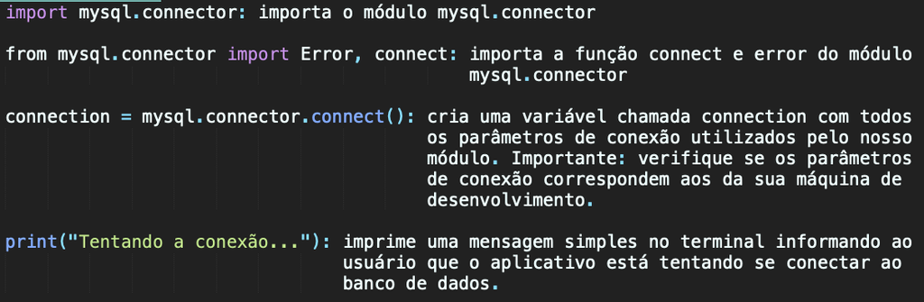

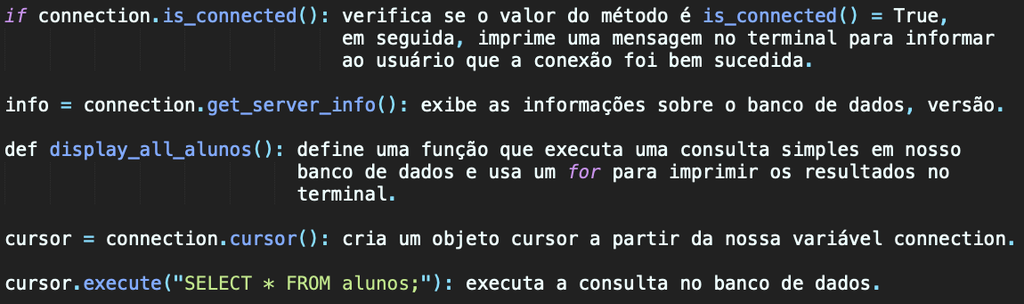

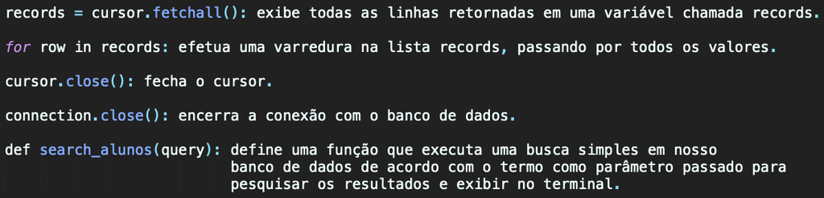

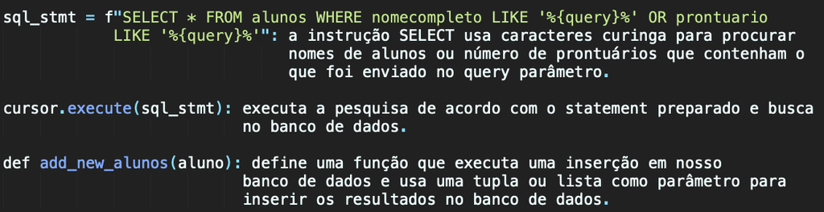

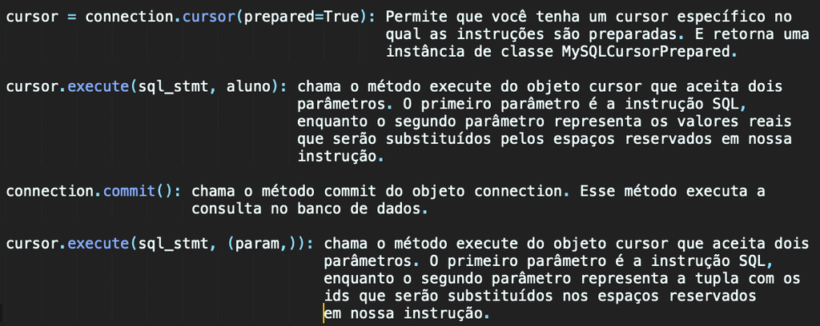

### 4. Executando um Exemplo

- **As informações a seguir deverão ser revisadas, pois com a atualização da linguagem, algumas instruções são modificadas**. Além do uso de uma IDE específica, um conector específico etc.
- **Existem outras formas de codificação, de simplificação etc**.

```python
# Arquivo conexao.py
# Utilizando o conector do Python específico para mysql.
import mysql.connector
from mysql.connector import errorcode


class Conexao:

    def __init__(self, user, password, database):
        self.user = user
        self.password = password
        self.database = database

    def abrir(self):
        try:
            cnx = mysql.connector.connect(user=self.user, password=self.password, database=self.database)
            print("Testando a conexão...")
            if cnx.is_connected():
                info = cnx.get_server_info()
                print("Conectado com sucesso ao Servidor MySQL versão: ", info)
                return True
        except mysql.connector.Error as err:
            print("Um erro ocorreu durante a conexão com o BD MySQL.")
            if err.errno == errorcode.ER_ACCESS_DENIED_ERROR:
                print("Algum problema com o usuário e senha.\n", err)
            elif err.errno == errorcode.ER_BAD_DB_ERROR:
                print("Banco de dados não existe.", err)
            else:
                print(err)
        else:
            cnx.close()
```

```python
# Arquivo principal.py
#
from aluno import Aluno
from conexao import Conexao as conecta


#user = input("Informe o usuário de conexão com o BD: ")
#password = input("Informe a senha de conexão com o BD: ")
#database = input("Informe o banco de dados: ")
n = conecta('root', 'senha', 'lp2i2')
#n = aluno(user, password, database)
valor = n.abrir()
if valor:
    aluno = Aluno('root', 'senha', 'lp2i2')
    print("Conexão efetuada com sucesso!")


    def menu():
        title = "Manutenção de Alunos"
        print("\n")
        print('-' * len(title))
        print(title)
        print('-' * len(title))
        print('')
        print('Selecione uma opção para Alunos. Digite 0 para sair.')
        print('')
        print('1. Exibir todos os alunos.')
        print('2. Adicionar.')
        print('3. Pesquisar.')
        print('4. Atualizar.')
        print('5. Excluir.\n')
        choice = int(input("Entre com o número da opção: "))
        print('')
        return choice

    choice = menu()
    while choice != 0:
        if choice == 1:
            aluno.display_all_alunos()
        elif choice == 2:
            termoins = [input("Prontuário: ").upper(), input("Nome Completo: ").title()]
            pessoalins = [input("Sexo: ").upper(), int(input("Idade: ")), input("Cor dos olhos: ")]
            aluno.add_new_alunos(termoins, pessoalins)
        elif choice == 3:
            termo = input("Entre com o termo de busca (prontuário ou nome): ")
            aluno.search_alunos(termo)
        elif choice == 4:
            aluno_id = input("Entre com o idaluno: ")
            prontuario = input("Prontuário: ").upper()
            nomecompleto = input("Nome Completo: ").title()
            sexo = input("Sexo: ").upper()
            idade = input("Idade: ")
            cordeolhos = input("Cor de olhos: ").title()
            alunod = (prontuario, nomecompleto, aluno_id)
            alunop = (sexo, idade, cordeolhos, aluno_id)
            aluno.update_alunos(alunod, alunop)
        elif choice == 5:
            aluno_id = input("Entre com o idaluno: ")
            aluno.delete_alunos(aluno_id)
        else:
            print("Opção inválida. Por favor, selecione um número entre 1 e 5.")
        choice = menu()
    else:
        print("Obrigada por vir!")
else:
    print("Não foi possível exibir o menu de opções devido ao erro anterior!")
```

```python
# Arquivo aluno.py
#
import mysql.connector
from conexao import Conexao


class Aluno():

    def __init__(self, user, password, database):
        self.user = user
        self.password = password
        self.database = database

    def display_all_alunos(self):
        """Método para exibir todos os alunos do BD."""
        cnx = mysql.connector.connect(user=self.user, password=self.password, database=self.database)
        cursor = cnx.cursor(prepared=True)
        cursor.execute("SELECT idaluno, prontuario, nomecompleto, alunopessoal.sexo, alunopessoal.idade, alunopessoal.cordeolhos "
                       "FROM alunos INNER JOIN alunopessoal "
                       "where idaluno = alunopessoalid;")
        records = cursor.fetchall()
        heading = f"Total de alunos registrados no sistema: {cursor.rowcount} alunos."
        print(heading)
        print("-" * len(heading))
        for row in records:
            print(f"ID: {row[0]}")
            print(f"Prontuario: {row[1]}")
            print(f"Nome: {row[2]}")
            print(f"Sexo: {row[3]}")
            print(f"Idade: {row[4]}")
            print(f"Cor de Olhos: {row[5]}\n")
            cursor.close()
        cnx.close()
        print("A conexão com o BD Mysql foi fechada.")

    def search_alunos(self, query):
        """Método para selecionar alunos específicos do BD."""
        sql_stmt = f"SELECT idaluno, prontuario, nomecompleto, alunopessoal.sexo, alunopessoal.idade, alunopessoal.cordeolhos " \
                   f"FROM alunos INNER JOIN alunopessoal " \
                   f"WHERE idaluno = alunopessoalid AND (nomecompleto LIKE '%{query}%' OR prontuario LIKE '%{query}%')"
        cnx = mysql.connector.connect(user=self.user, password=self.password, database=self.database)
        cursor = cnx.cursor(prepared=True)
        cursor.execute(sql_stmt)
        records = cursor.fetchall()
        heading = f"A pesquisa para '{query}' retornou: {cursor.rowcount} linhas."
        print(heading)
        print("-" * len(heading))
        for row in records:
            print(f"ID: {row[0]}")
            print(f"Prontuario: {row[1]}")
            print(f"Nome: {row[2]}")
            print(f"Sexo: {row[3]}")
            print(f"Idade: {row[4]}")
            print(f"Cor de Olhos: {row[5]}\n")

        cursor.close()
        cnx.close()
        print("A conexão com o BD Mysql foi fechada.")

    def add_new_alunos(self, aluno, dadosaluno):
        """Método para inserir alunos do BD."""
        sql_stmt = "INSERT INTO alunos (prontuario, nomecompleto) VALUES (%s,%s)"
        cnx = mysql.connector.connect(user=self.user, password=self.password, database=self.database)
        cursor = cnx.cursor(prepared=True)
        cursor.execute(sql_stmt, aluno)
        cnx.commit()
        ultreg = cursor.lastrowid
        cursor.close()
        cnx.close()
        print("O registro de Aluno foi inserido com sucesso no BD!")

        alunopessoalid = ultreg
        dadosaluno.append(alunopessoalid)
        sql_stmt1 = "INSERT INTO alunopessoal (sexo, idade, cordeolhos, alunopessoalid) VALUES (%s,%s,%s,%s)"
        cnx1 = mysql.connector.connect(user=self.user, password=self.password, database=self.database)
        cursor1 = cnx1.cursor(prepared=True)
        cursor1.execute(sql_stmt1, dadosaluno)
        cnx1.commit()
        cursor1.close()
        cnx1.close()
        print("O registro de Dados Pessoais do Aluno foi inserido com sucesso no BD!")

    def update_alunos(self, aluno, alunop):
        """Método para atualizar alunos do BD."""
        sql_stmt = "UPDATE alunos SET prontuario = %s, nomecompleto = %s WHERE idaluno = %s"
        cnx = mysql.connector.connect(user=self.user, password=self.password, database=self.database)
        cursor = cnx.cursor(prepared=True)
        cursor.execute(sql_stmt, aluno)
        cnx.commit()
        cursor.close()
        cnx.close()
        print("O registro de Aluno foi atualizado com sucesso no BD!")

        sql_stmt1 = "UPDATE alunopessoal SET sexo = %s, idade = %s, cordeolhos = %s WHERE alunopessoalid = %s"
        cnx1 = mysql.connector.connect(user=self.user, password=self.password, database=self.database)
        cursor1 = cnx1.cursor(prepared=True)
        cursor1.execute(sql_stmt1, alunop)
        cnx1.commit()
        cursor1.close()
        cnx1.close()
        print("O registro de Dados Pessoais do Aluno foi atualizado com sucesso no BD!")

    def delete_alunos(self, aluno):
        """Método para excluir alunos do BD."""
        sql_stmt1 = "DELETE FROM alunopessoal WHERE alunopessoalid = %s"
        param = aluno
        cnx1 = mysql.connector.connect(user=self.user, password=self.password, database=self.database)
        cursor1 = cnx1.cursor(prepared=True)
        cursor1.execute(sql_stmt1, (param,))
        cnx1.commit()
        cursor1.close()
        cnx1.close()
        print("O registro de Dados Pessoais do Aluno foi excluído com sucesso do BD!")

        sql_stmt = "DELETE FROM alunos WHERE idaluno = %s"
        cnx = mysql.connector.connect(user=self.user, password=self.password, database=self.database)
        cursor = cnx.cursor(prepared=True)
        cursor.execute(sql_stmt, (param,))
        cnx.commit()
        cursor.close()
        cnx.close()
        print("O registro de Alunos foi excluído com sucesso do BD!")
```

### Exercícios para resolver em sala

- **Exercício**: Refatorar o código: Melhorando todas os métodos, otimizando, diminuindo codificação.
- Entregar no link apropriado no moodle.

### Referências

- Esta aula foi elaborada a partir do conteúdo disponibilizado no [Python Dev](https://www.python.org/dev/) e [Site Oficial](https://docs.python.org/3/).
- [Orestes, Yan](https://www.alura.com.br/artigos/o-que-significa-if-name-main-no-python). O que significa if name == ' main ' no Python? 2018. Disponível em: https://www.alura.com.br/artigos/o-que-significa-if-name-main-no-python. Acesso em: 23 jun. 2020.

### Perguntas

- Esclareça suas eventuais dúvidas durante as aulas.
- Ou pelo *E-mail*: paulagiancoli@ifsp.edu.br.
- Ou pelo *Fórum* do componente curricular.
- Ou acesse [Github Ana Giancoli](https://anagiancoli.github.io) e solicite atendimento para o componente curricular.

*ADS - Python versão 3.7 - 2o. módulo*.  
Modelo e formato elaborado por profa. Ana Paula Müller Giancoli - BSD 2-Clause License. - Julho.2020.